# Penanganan Autokorelasi - Tugas 2 MPDW

Bryant

# Import Packages

```r
library(dplyr)
library(lmtest)
library(lubridate)
library(prais)
```

# Import Data & Praproses Data

```r
IPM <- read.csv("D:\\Kuliah\\Sem 5\\MPDW\\Pertemuan 2\\ipm_sulawesi_selatan_time_series_updated.csv")
IPM <- IPM %>%
  rename(Tahun = Wilayah)

IPM
```

| Tahun | Bulukumba | Bantaeng | Jeneponto | Takalar | Gowa | Sinjai | Maros | Pangkajene.dan.Kepulauan | Barru | Bone | Soppeng | Wajo | Sindereng.Rappang | Pinrang | Enrekang | Luwu | Tana.Toraja | Luwu.Utara | Luwu.Timur | Toraja.Utara | Makassar | Parepare | Palopo | Sulawesi.Selatan |
| --- | --- | --- | --- | --- | --- | --- | --- | --- | --- | --- | --- | --- | --- | --- | --- | --- | --- | --- | --- | --- | --- | --- | --- | --- |
| 2010 | 62.73 | 62.46 | 58.31 | 60.23 | 63.83 | 61.31 | 64.07 | 62.79 | 64.94 | 59.69 | 63.51 | 63.07 | 65.54 | 66.25 | 66.27 | 63.95 | 62.83 | 64.77 | 68.47 | 63.51 | 77.63 | 73.55 | 73.03 | 66.00 |
| 2011 | 63.36 | 63.07 | 58.95 | 60.83 | 64.42 | 62.13 | 64.95 | 63.60 | 65.73 | 60.21 | 63.80 | 64.00 | 65.88 | 66.96 | 67.03 | 64.71 | 63.22 | 65.57 | 68.94 | 64.48 | 77.82 | 74.20 | 74.02 | 66.65 |
| 2012 | 63.82 | 63.99 | 59.62 | 61.66 | 64.65 | 62.74 | 65.50 | 64.30 | 66.07 | 60.77 | 64.05 | 64.88 | 66.19 | 67.64 | 67.74 | 65.43 | 63.96 | 65.99 | 69.34 | 64.89 | 78.47 | 74.67 | 74.54 | 67.26 |
| 2013 | 64.27 | 64.88 | 60.55 | 62.58 | 65.45 | 63.47 | 66.06 | 65.24 | 67.02 | 61.40 | 64.43 | 65.79 | 67.15 | 68.14 | 68.39 | 66.39 | 64.55 | 66.40 | 69.53 | 65.65 | 78.98 | 75.10 | 75.02 | 67.92 |
| 2014 | 65.24 | 65.77 | 61.45 | 63.53 | 66.12 | 63.83 | 66.65 | 66.16 | 67.94 | 62.09 | 64.74 | 66.49 | 68.14 | 68.92 | 69.37 | 67.34 | 65.08 | 66.90 | 69.75 | 66.15 | 79.35 | 75.66 | 75.65 | 68.49 |
| 2015 | 65.58 | 66.20 | 61.61 | 64.07 | 66.87 | 64.48 | 67.13 | 66.65 | 68.64 | 63.11 | 65.33 | 66.90 | 69.00 | 69.24 | 70.03 | 68.11 | 65.75 | 67.44 | 70.43 | 66.76 | 79.94 | 76.31 | 76.27 | 69.15 |
| 2016 | 66.46 | 66.59 | 61.81 | 64.96 | 67.70 | 65.36 | 67.76 | 66.86 | 69.07 | 63.86 | 65.95 | 67.52 | 69.39 | 69.42 | 70.79 | 68.71 | 66.25 | 67.81 | 70.95 | 67.49 | 80.53 | 76.48 | 76.45 | 69.76 |
| 2017 | 67.08 | 67.27 | 62.67 | 65.48 | 68.33 | 65.80 | 68.42 | 67.25 | 69.56 | 64.16 | 66.67 | 68.18 | 69.84 | 69.90 | 71.44 | 69.02 | 66.82 | 68.35 | 71.46 | 67.90 | 81.13 | 76.68 | 76.71 | 70.34 |
| 2018 | 67.70 | 67.76 | 63.33 | 66.07 | 68.87 | 66.24 | 68.94 | 67.71 | 70.05 | 65.04 | 67.60 | 68.57 | 70.60 | 70.62 | 72.15 | 69.60 | 67.66 | 68.79 | 72.16 | 68.49 | 81.73 | 77.19 | 77.30 | 70.90 |
| 2019 | 68.28 | 68.30 | 64.00 | 66.94 | 69.66 | 67.05 | 69.50 | 68.29 | 70.60 | 65.67 | 68.26 | 69.05 | 71.05 | 71.12 | 72.66 | 70.39 | 68.25 | 69.46 | 72.80 | 69.23 | 82.25 | 77.62 | 77.98 | 71.66 |

[output cut: 2 more lines]

```r
IPM_Makassar <- IPM %>%
  select(c("Makassar","Tahun"))%>%
  rename(IPM = Makassar)
IPM_Makassar.ts <- ts(IPM_Makassar)
IPM_Makassar.ts
```

```
## Time Series:
## Start = 1
## End = 12
## Frequency = 1
##      IPM Tahun
##  1 77.63  2010
##  2 77.82  2011
##  3 78.47  2012
##  4 78.98  2013
##  5 79.35  2014
##  6 79.94  2015
##  7 80.53  2016
##  8 81.13  2017
##  9 81.73  2018
## 10 82.25  2019
## 11 82.25  2020
## 12 82.66  2021
```

Mengambil kolom IPM Kota Makassar dan mengubahnya menjadi data time series

# Ekplorasi Data

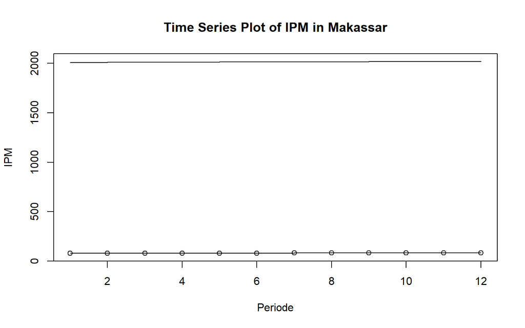

```r
ts.plot(IPM_Makassar.ts, ylab = "IPM", xlab = "Periode", main = "Time Series Plot of IPM in Makassar")
points(IPM_Makassar.ts)
```

Berdasarkan plot di atas, adanya tren naik pada IPM Makassar

Karena tujuan awal akan menggunakan Regresi Linear Sederhana, tidak akan dilakukan pemulusan pada data dikarenakan pemulusan bisa mengubah informasi dari data asli.

# Regresi

## Model Awal

```r
model <- lm(IPM ~ Tahun, data = IPM_Makassar)
summary(model)
```

```
##
## Call:
## lm(formula = IPM ~ Tahun, data = IPM_Makassar)
##
## Residuals:
##      Min       1Q   Median       3Q      Max
## -0.28641 -0.14889 -0.02075  0.12990  0.29198
##
## Coefficients:
##               Estimate Std. Error t value Pr(>|t|)
## (Intercept) -915.82331   32.74931  -27.96 7.94e-11 ***
## Tahun          0.49420    0.01625   30.41 3.46e-11 ***
## ---
## Signif. codes:  0 '***' 0.001 '**' 0.01 '*' 0.05 '.' 0.1 ' ' 1
##
## Residual standard error: 0.1943 on 10 degrees of freedom
## Multiple R-squared:  0.9893, Adjusted R-squared:  0.9882
## F-statistic:   925 on 1 and 10 DF,  p-value: 3.459e-11
```

Berdasarkan ringkasan model di atas didapatkan model
$$y_i = -915.823 + 0.494x_i$$
didapatkan
$$R^2$$
sebesar 0.989 yang berarti keragaman nilai IPM dapat dijelaskan oleh peubah tahun. Hal ini memperlihatkan model tersebut adalah model terbaik. Namun, kita perlu menguji sisaan pada model.

### Uji Sisaan

#### Ekplorasi Data

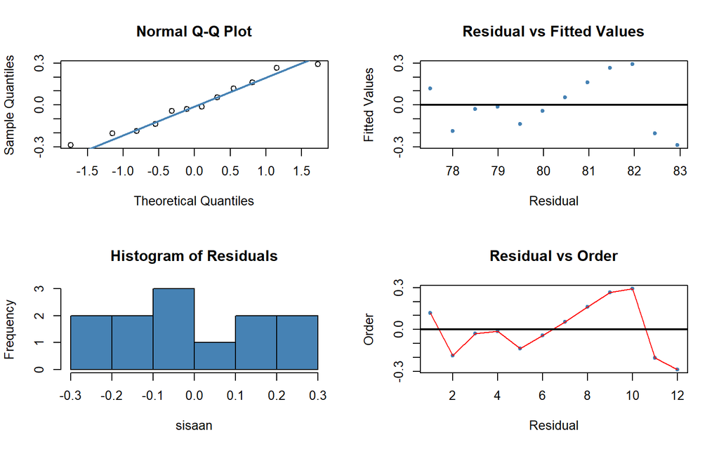

```r
#sisaan dan fitted value
sisaan<- residuals(model)
fitValue<- predict(model)

#Diagnostik dengan eksploratif
par(mfrow = c(2,2))
qqnorm(sisaan)
qqline(sisaan, col = "steelblue", lwd = 2)
plot(fitValue, sisaan, col = "steelblue", pch = 20, xlab = "Residual", ylab = "Fitted Values", main = "Residual vs Fitted Values")
abline(a = 0, b = 0, lwd = 2)
hist(sisaan, col = "steelblue", nclass = 8, main = "Histogram of Residuals")
plot(seq(1,12,1), sisaan, col = "steelblue", pch = 20, xlab = "Residual", ylab = "Order", main = "Residual vs Order")
lines(seq(1,12,1), sisaan, col = "red")
abline(a = 0, b = 0, lwd = 2)
```

Berdasarkan QQ Plot sebaran sisaan cenderung mengikuti garis yang berarti sebarannya normal. Pada Histogram pun memperlihatkan sisaan cenderung normal, walau tak sempurna.

Berdasarkan plot Residual vs Fitted dan Residual vs Order menunjukkan adanya pola yang mengindikasikan adanya autokorelasi.

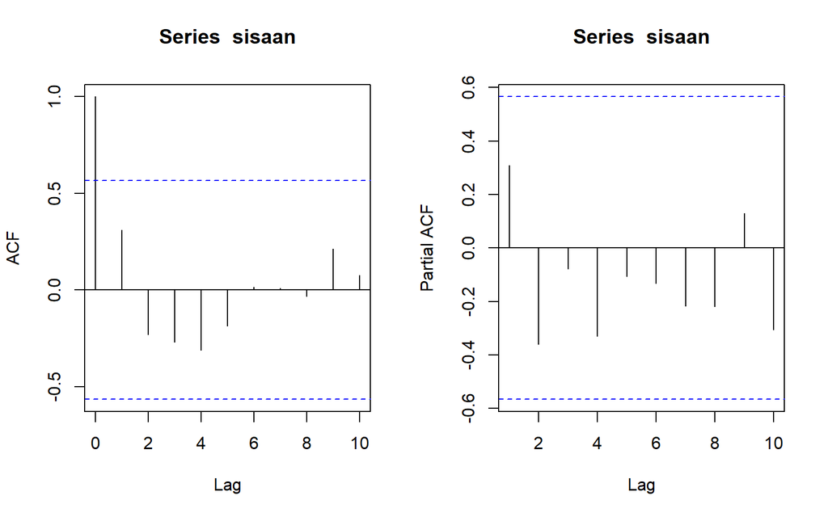

```r
par(mfrow = c(1,2))
acf(sisaan)
pacf(sisaan)
```

Berdasarkan plot ACF dan PACF tidak ada lag yang signifikan.

### Uji Formal

Selanjutnya dilakukan uji formal untuk menguji normalitas dan autokorelasi.

### Normalitas

H0: sisaan mengikuti sebaran normal  
H1: sisaan tidak mengikuti sebaran normal

```r
shapiro.test(sisaan)
```

```
##
##  Shapiro-Wilk normality test
##
## data:  sisaan
## W = 0.96439, p-value = 0.8441
```

Berdasarkan uji formal Shapiro Wilk, p-value = 0.844 > 0.05 =
$$\alpha$$
Cukup bukti untuk menyatakan sisaan menyebar normal

#### Autokorelasi

H0: tidak ada autokorelasi  
H1: ada autokorelasi

```r
dwtest(model)
```

```
##
##  Durbin-Watson test
##
## data:  model
## DW = 1.1262, p-value = 0.01863
## alternative hypothesis: true autocorrelation is greater than 0
```

Berdasarkan uji formal Durbin Watson p-value = 0.018 < 0.05 =
$$\alpha$$
Cukup bukti untuk menyatakan bahwa ada autokorelasi

Oleh karena itu, diperlukan untuk penanganan terhadap autokorelasi.

## Penanganan Autokorelasi

### Metode Hildreth Lu

```r
hildreth.lu.func<- function(r, model){
  x <- model.matrix(model)[,-1]
  y <- model.response(model.frame(model))
  n <- length(y)
  t <- 2:n
  y <- y[t]-r*y[t-1]
  x <- x[t]-r*x[t-1]

  return(lm(y~x))
}
```

```r
r <- c(seq(0.1,0.9, by= 0.1))
tab <- data.frame("rho" = r, "SSE" = sapply(r, function(i){deviance(hildreth.lu.func(i, model))}))
round(tab, 4)
```

| rho | SSE |
| --- | --- |
| 0.1 | 0.3381 |
| 0.2 | 0.3242 |
| 0.3 | 0.3155 |
| 0.4 | 0.3121 |
| 0.5 | 0.3139 |
| 0.6 | 0.3209 |
| 0.7 | 0.3331 |
| 0.8 | 0.3506 |
| 0.9 | 0.3732 |

```r
r <- c(seq(0.3,0.5, by= 0.01))
tab <- data.frame("rho" = r, "SSE" = sapply(r, function(i){deviance(hildreth.lu.func(i, model))}))
round(tab, 4)
```

| rho | SSE |
| --- | --- |
| 0.30 | 0.3155 |
| 0.31 | 0.3150 |
| 0.32 | 0.3144 |
| 0.33 | 0.3140 |
| 0.34 | 0.3135 |
| 0.35 | 0.3132 |
| 0.36 | 0.3128 |
| 0.37 | 0.3126 |
| 0.38 | 0.3124 |
| 0.39 | 0.3122 |

[output cut: 11 more lines]

```r
r <- c(seq(0.41,0.42, by= 0.001))
tab <- data.frame("rho" = r, "SSE" = sapply(r, function(i){deviance(hildreth.lu.func(i, model))}))
round(tab, 4)
```

| rho | SSE |
| --- | --- |
| 0.410 | 0.312 |
| 0.411 | 0.312 |
| 0.412 | 0.312 |
| 0.413 | 0.312 |
| 0.414 | 0.312 |
| 0.415 | 0.312 |
| 0.416 | 0.312 |
| 0.417 | 0.312 |
| 0.418 | 0.312 |
| 0.419 | 0.312 |

[output cut: 1 more lines]

$\rho$ dengan SSE terkecil didapatkan 0.41

```r
modelHL <- hildreth.lu.func(0.41, model)
summary(modelHL)
```

```
##
## Call:
## lm(formula = y ~ x)
##
## Residuals:
##      Min       1Q   Median       3Q      Max
## -0.30087 -0.14627  0.03664  0.12624  0.22173
##
## Coefficients:
##               Estimate Std. Error t value Pr(>|t|)
## (Intercept) -540.61201   35.80321  -15.10 1.07e-07 ***
## x              0.49441    0.03009   16.43 5.10e-08 ***
## ---
## Signif. codes:  0 '***' 0.001 '**' 0.01 '*' 0.05 '.' 0.1 ' ' 1
##
## Residual standard error: 0.1862 on 9 degrees of freedom
## Multiple R-squared:  0.9677, Adjusted R-squared:  0.9642
## F-statistic:   270 on 1 and 9 DF,  p-value: 5.101e-08
```

```r
cat("y = ", coef(modelHL)[1]/(1-0.341), "+", coef(modelHL)[2],"x", sep = "")
```

```
## y = -820.3521+0.4944099x
```

Setelah ditransformasi didapatkan persamaan berikut

```r
dwtest(modelHL)
```

```
##
##  Durbin-Watson test
##
## data:  modelHL
## DW = 1.2827, p-value = 0.04227
## alternative hypothesis: true autocorrelation is greater than 0
```

Hasil uji Durbin-Watson juga menunjukkan bawah nilai DW sebesar $1.2827$ berada pada selang daerah inkonklusif, yaitu pada rentang DL < DW < DU atau $0.971 < DW < 1.331$. Namun, berdasarkan *p-value* < 0.05 menunjukkan bahwa ada autokorelasi. Oleh karena itu, metode Hildreth Lu belum cukup untuk menangani autokorelasi pada model ini.

### Metode Cochrane Orcutt

```r
rho <- 0.410

ipm.trans<- IPM_Makassar[-1,1]-IPM_Makassar[-12,1]*rho
tahun.trans<- IPM_Makassar[-1,2]-IPM_Makassar[-12,2]*rho

modelCO<- lm(ipm.trans~tahun.trans)
summary(modelCO)
```

```
##
## Call:
## lm(formula = ipm.trans ~ tahun.trans)
##
## Residuals:
##      Min       1Q   Median       3Q      Max
## -0.30087 -0.14627  0.03664  0.12624  0.22173
##
## Coefficients:
##               Estimate Std. Error t value Pr(>|t|)
## (Intercept) -540.61201   35.80321  -15.10 1.07e-07 ***
## tahun.trans    0.49441    0.03009   16.43 5.10e-08 ***
## ---
## Signif. codes:  0 '***' 0.001 '**' 0.01 '*' 0.05 '.' 0.1 ' ' 1
##
## Residual standard error: 0.1862 on 9 degrees of freedom
## Multiple R-squared:  0.9677, Adjusted R-squared:  0.9642
## F-statistic:   270 on 1 and 9 DF,  p-value: 5.101e-08
```

```r
b0bintang <- modelCO$coefficients[-2]
b0 <- b0bintang/(1-rho)
b1 <- modelCO$coefficients[-1]
b0
```

```
## (Intercept)
##   -916.2915
```

```r
b1
```

```
## tahun.trans
##   0.4944099
```

```r
dwtest(modelCO)
```

```
##
##  Durbin-Watson test
##
## data:  modelCO
## DW = 1.2827, p-value = 0.04227
## alternative hypothesis: true autocorrelation is greater than 0
```

Hasil uji Durbin-Watson juga menunjukkan bawah nilai DW sebesar $1.2827$ berada pada selang daerah inkonklusif, yaitu pada rentang DL < DW < DU atau $0.971 < DW < 1.331$. Namun, berdasarkan *p-value* < 0.05 menunjukkan bahwa ada autokorelasi. Oleh karena itu, metode Cochrane Orcutt juga belum cukup untuk menangani autokorelasi pada model ini.

### Metode Prais Winsten

Selanjutnya dilakukan metode Prais Winsten, karena kedua metode tersebut belum dapat menangani masalah autokorelasi.

```r
modelPW <- prais_winsten(IPM~Tahun, data = IPM_Makassar, index = "Tahun")
```

```
## Iteration 0: rho = 0
## Iteration 1: rho = 0.3951
## Iteration 2: rho = 0.4534
## Iteration 3: rho = 0.4677
## Iteration 4: rho = 0.4715
## Iteration 5: rho = 0.4726
## Iteration 6: rho = 0.4728
## Iteration 7: rho = 0.4729
## Iteration 8: rho = 0.4729
## Iteration 9: rho = 0.4729
## Iteration 10: rho = 0.4729
## Iteration 11: rho = 0.4729
```

```r
summary(modelPW)
```

```
##
## Call:
## prais_winsten(formula = IPM ~ Tahun, data = IPM_Makassar, index = "Tahun")
##
## Residuals:
##      Min       1Q   Median       3Q      Max
## -0.22977 -0.13764 -0.03492  0.10122  0.34651
##
## AR(1) coefficient rho after 11 iterations: 0.4729
##
## Coefficients:
##              Estimate Std. Error t value Pr(>|t|)
## (Intercept) -890.6795    46.5585  -19.13 3.31e-09 ***
## Tahun          0.4817     0.0231   20.85 1.43e-09 ***
## ---
## Signif. codes:  0 '***' 0.001 '**' 0.01 '*' 0.05 '.' 0.1 ' ' 1
##
## Residual standard error: 0.1789 on 10 degrees of freedom
## Multiple R-squared:  0.9995, Adjusted R-squared:  0.9994
## F-statistic: 1.925e+04 on 1 and 10 DF,  p-value: < 2.2e-16
##
## Durbin-Watson statistic (original): 1.126
## Durbin-Watson statistic (transformed): 1.632
```

Berdasarkan uji Durbin Watson menunjukkan bahwa nilai DW meningkat menjadi $1.632$. Nilai DW sudah berada pada rentang DU < DW < 4-DU atau $1.331 < DW < 2.669$. Maka, sudah tidak ada autokorelasi. Metode Prais Winsten dapat menangani autokorelasi dengan baik pada model ini.

## Perbandingan Metode Terbaik

Metode terbaik dipilih berdasarkan SSE terendah

```r
sseModelawal <- anova(model)$`Sum Sq`[-1]
sseModelPW <- sum(residuals(modelPW)^2)
sseModelCO <- anova(modelCO)$`Sum Sq`[-1]
sseModelHL <- anova(modelHL)$`Sum Sq`[-1]
mseModelawal <- sseModelawal/length(IPM_Makassar[,1])
mseModelPW <- sseModelPW/length(IPM_Makassar[,1])
mseModelCO <- sseModelCO/length(IPM_Makassar[,1])
mseModelHL <- sseModelHL/length(IPM_Makassar[,1])
akurasi <- matrix(c(sseModelawal,sseModelPW,sseModelCO,sseModelHL,
                    mseModelawal,mseModelPW,mseModelCO,mseModelHL),nrow=2,ncol=4,byrow = T)
colnames(akurasi) <- c("Model Awal","Model Prais Winsten", "Model Cochrane-Orcutt", "Model Hildreth-Lu")
row.names(akurasi) <- c("SSE","MSE")
akurasi
```

```
##     Model Awal Model Prais Winsten Model Cochrane-Orcutt Model Hildreth-Lu
## SSE 0.37754918          0.40123408            0.31203097        0.31203097
## MSE 0.03146243          0.03343617            0.02600258        0.02600258
```

Berdasarkan hasil tersebut diketahui bahwa hasil penanganan autokorelasi dengan metode Hildreth Lu dan metode Cochrane Orcutt menghasilkan SSE yang sama, sebesar $0.3120$. Kedua metode tersebut memiliki nilai SSE terendah, tetapi belum bisa menangani autokorelasi. Maka, metode yang kita gunakan adalah metode Prais Winsten dengan SSE bernilai $0.4012$.

# Simpulan

Autokorelasi seringkali muncul pada data Indeks Pembangunan Manusia (IPM) akibat korelasi yang kuat antar komponennya, khususnya indikator ekonomi. Kehadiran autokorelasi ini dapat mengganggu validitas model regresi, membuatnya menjadi kurang bisa diandalkan.

Masalah ini dapat dideteksi melalui analisis visual seperti plot sisaan, ACF, dan PACF, atau melalui uji formal seperti Durbin-Watson. Untuk menanganinya, dapat digunakan beberapa metode seperti Hildreth-Lu, Cochrane-Orcutt, dan Prais-Winsten. Meskipun, nilai SSE dengan metode Prais-Winsten paling besar, metode ini dapat mengatasi autokorelasi dengan baik pada model ini.